# Trabalho_SerieTemporal_Unifor_Diego_Teixeira

UNIVERSIDADE DE FORTALEZA

MBA Ciência de Dados

**Nome: DiegoTeixeira Marques**

**E-mail: diegoteixeira1996@gmail.com**

**Matrícula: 1924526**

**Disciplina: Séries Temporais**

### 1. Introdução

Este trabalho visa aplicar um modelo auto autorregressivo (AR) para prever o volume de entradas de processos para um cliente específico de um escritório de advocacia em Fortaleza-CE. Os dados foram rotulados para manter o anonimato.

### 2. Metodologia

Inicialmente foi realizado um tratamento nos dados para mantê-los numa granularidade mensal, depois foram vistos através de gráficos para entender sobre sua tendência e padronização. Por fim, aplica-se o modelo para prever os resultados e é calculado o erro quadrático médio para cada um.

### 3. Importando bibliotecas

```python
import pandas as pd
import numpy as np
import matplotlib.pyplot as plt
import openpyxl
import datetime
```

### 4. Carregando e visualizando os dados

**Observa-se que há 3 colunas no dataset que são referentes a um cliente apelidado de `Cliente 54`. É percebido que os dados são referentes as entradas diárias de processos deste cliente.**

```python
df = pd.read_excel(
        open(r'BaseEntradasProcessos.xlsx', 'rb'),
        sheet_name='Entradas', engine='openpyxl')

df
```

|  | dataRecebimento | cliente | qtd |
| --- | --- | --- | --- |
| 0 | 2019-09-09 13:45:17.753 | Cliente 54 | 1 |
| 1 | 2019-09-09 13:56:00.886 | Cliente 54 | 1 |
| 2 | 2019-09-09 14:02:31.586 | Cliente 54 | 1 |
| 3 | 2019-09-09 14:09:22.200 | Cliente 54 | 1 |
| 4 | 2019-09-09 17:01:45.927 | Cliente 54 | 1 |
| ... | ... | ... | ... |
| 1050 | 2021-02-11 18:23:57.813 | Cliente 54 | 1 |
| 1051 | 2021-02-12 13:09:08.285 | Cliente 54 | 1 |
| 1052 | 2021-02-12 13:17:08.969 | Cliente 54 | 1 |
| 1053 | 2021-02-12 13:19:29.696 | Cliente 54 | 1 |
| 1054 | 2021-02-12 13:21:51.978 | Cliente 54 | 1 |

1055 rows × 3 columns

```python
df.info()
```

```
<class 'pandas.core.frame.DataFrame'>
RangeIndex: 1055 entries, 0 to 1054
Data columns (total 3 columns):
 #   Column           Non-Null Count  Dtype
---  ------           --------------  -----
 0   dataRecebimento  1055 non-null   datetime64[ns]
 1   cliente          1055 non-null   object
 2   qtd              1055 non-null   int64
dtypes: datetime64[ns](1), int64(1), object(1)
memory usage: 24.9+ KB
```

**A base de dados possui 1055 linhas. Vamos visualizar os dados conforme foi carregado...**

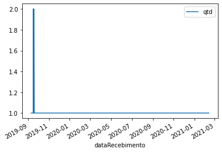

```python
df1 = df.copy()
df1.set_index('dataRecebimento', inplace=True)
df1.plot()
```

**Devido a granularidade das datas, a visualização não permite ter uma boa ideia de como se comporta os volume de entrada dos processos. Assim, a seguir vamos tratar os dados para que tenhamos uma visualização mensal das quantidades.**

### 5. Higienizando os dados

**Para criar uma visualização mensal das quantidades, primeiro vamos separar ano e mês em duas colunas. Posteriormente faremos o agrupamento somando as quantidades.**

```python
df['ano'] = pd.to_datetime(df.dataRecebimento).dt.strftime('%Y')
df['mes'] = pd.to_datetime(df.dataRecebimento).dt.strftime('%m')
df
```

|  | dataRecebimento | cliente | qtd | ano | mes |
| --- | --- | --- | --- | --- | --- |
| 0 | 2019-09-09 13:45:17.753 | Cliente 54 | 1 | 2019 | 09 |
| 1 | 2019-09-09 13:56:00.886 | Cliente 54 | 1 | 2019 | 09 |
| 2 | 2019-09-09 14:02:31.586 | Cliente 54 | 1 | 2019 | 09 |
| 3 | 2019-09-09 14:09:22.200 | Cliente 54 | 1 | 2019 | 09 |
| 4 | 2019-09-09 17:01:45.927 | Cliente 54 | 1 | 2019 | 09 |
| ... | ... | ... | ... | ... | ... |
| 1050 | 2021-02-11 18:23:57.813 | Cliente 54 | 1 | 2021 | 02 |
| 1051 | 2021-02-12 13:09:08.285 | Cliente 54 | 1 | 2021 | 02 |
| 1052 | 2021-02-12 13:17:08.969 | Cliente 54 | 1 | 2021 | 02 |
| 1053 | 2021-02-12 13:19:29.696 | Cliente 54 | 1 | 2021 | 02 |
| 1054 | 2021-02-12 13:21:51.978 | Cliente 54 | 1 | 2021 | 02 |

1055 rows × 5 columns

**Agrupando os dados por `ano` e `mes` e somando a coluna `qtd`**

```python
df = df.groupby(['ano', 'mes']).qtd.sum().reset_index()
df
```

|  | ano | mes | qtd |
| --- | --- | --- | --- |
| 0 | 2019 | 09 | 54 |
| 1 | 2019 | 10 | 66 |
| 2 | 2019 | 11 | 98 |
| 3 | 2019 | 12 | 60 |
| 4 | 2020 | 01 | 32 |
| 5 | 2020 | 02 | 62 |
| 6 | 2020 | 03 | 77 |
| 7 | 2020 | 04 | 50 |
| 8 | 2020 | 05 | 38 |
| 9 | 2020 | 06 | 58 |
| 10 | 2020 | 07 | 115 |
| 11 | 2020 | 08 | 79 |
| 12 | 2020 | 09 | 55 |
| 13 | 2020 | 10 | 58 |
| 14 | 2020 | 11 | 47 |
| 15 | 2020 | 12 | 40 |
| 16 | 2021 | 01 | 31 |
| 17 | 2021 | 02 | 37 |

**Convertendo as colunas `ano` e `mes` em inteiros para criar uma coluna data com o primeiro dia de cada mês utilizando a função `datetime()`**

```python
df['ano'] = df['ano'].astype(int)
df['mes'] = df['mes'].astype(int)
df.info()
```

```
<class 'pandas.core.frame.DataFrame'>
RangeIndex: 18 entries, 0 to 17
Data columns (total 3 columns):
 #   Column  Non-Null Count  Dtype
---  ------  --------------  -----
 0   ano     18 non-null     int32
 1   mes     18 non-null     int32
 2   qtd     18 non-null     int64
dtypes: int32(2), int64(1)
memory usage: 416.0 bytes
```

```python
df['data'] = ''
df.values
```

```
array([[2019, 9, 54, ''],
       [2019, 10, 66, ''],
       [2019, 11, 98, ''],
       [2019, 12, 60, ''],
       [2020, 1, 32, ''],
       [2020, 2, 62, ''],
       [2020, 3, 77, ''],
       [2020, 4, 50, ''],
       [2020, 5, 38, ''],
       [2020, 6, 58, ''],
       [2020, 7, 115, ''],
       [2020, 8, 79, ''],
       [2020, 9, 55, ''],
       [2020, 10, 58, ''],
       [2020, 11, 47, ''],
       [2020, 12, 40, ''],
       [2021, 1, 31, ''],
       [2021, 2, 37, '']], dtype=object)
```

```python
dados = []
for i in df.values:
    i[3] =  datetime.date(i[0], i[1], 1)
    dados.append(i)

df_dados = pd.DataFrame(dados, columns=['ano', 'mes', 'qtd', 'data'])
df_dados.drop(columns=['ano', 'mes'], inplace=True)
df_dados
```

|  | qtd | data |
| --- | --- | --- |
| 0 | 54 | 2019-09-01 |
| 1 | 66 | 2019-10-01 |
| 2 | 98 | 2019-11-01 |
| 3 | 60 | 2019-12-01 |
| 4 | 32 | 2020-01-01 |
| 5 | 62 | 2020-02-01 |
| 6 | 77 | 2020-03-01 |
| 7 | 50 | 2020-04-01 |
| 8 | 38 | 2020-05-01 |
| 9 | 58 | 2020-06-01 |
| 10 | 115 | 2020-07-01 |
| 11 | 79 | 2020-08-01 |
| 12 | 55 | 2020-09-01 |
| 13 | 58 | 2020-10-01 |
| 14 | 47 | 2020-11-01 |
| 15 | 40 | 2020-12-01 |
| 16 | 31 | 2021-01-01 |
| 17 | 37 | 2021-02-01 |

**Como podemos ver acima, temos um novo dataframe chamado `data_dados` com informação das entradas mensais de `01/09/2019` até `01/02/2021`**

**Agora... para utilizamos o modelo (AR) de forma mais prática vamos transformar a coluna `data` no index da coluna.**

```python
df_dados.set_index('data', inplace=True)
df_dados
```

| data | qtd |
| --- | --- |
| 2019-09-01 | 54 |
| 2019-10-01 | 66 |
| 2019-11-01 | 98 |
| 2019-12-01 | 60 |
| 2020-01-01 | 32 |
| 2020-02-01 | 62 |
| 2020-03-01 | 77 |
| 2020-04-01 | 50 |
| 2020-05-01 | 38 |
| 2020-06-01 | 58 |
| 2020-07-01 | 115 |
| 2020-08-01 | 79 |
| 2020-09-01 | 55 |
| 2020-10-01 | 58 |
| 2020-11-01 | 47 |
| 2020-12-01 | 40 |
| 2021-01-01 | 31 |
| 2021-02-01 | 37 |

### 6. Visualizando os dados agrupados

**Após as transformações é possível ver o comportamento dos dados de forma mais clara, vejamos abaixo...**

```python
df_dados.info()
```

```
<class 'pandas.core.frame.DataFrame'>
Index: 18 entries, 2019-09-01 to 2021-02-01
Data columns (total 1 columns):
 #   Column  Non-Null Count  Dtype
---  ------  --------------  -----
 0   qtd     18 non-null     int64
dtypes: int64(1)
memory usage: 288.0+ bytes
```

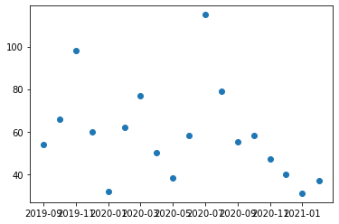

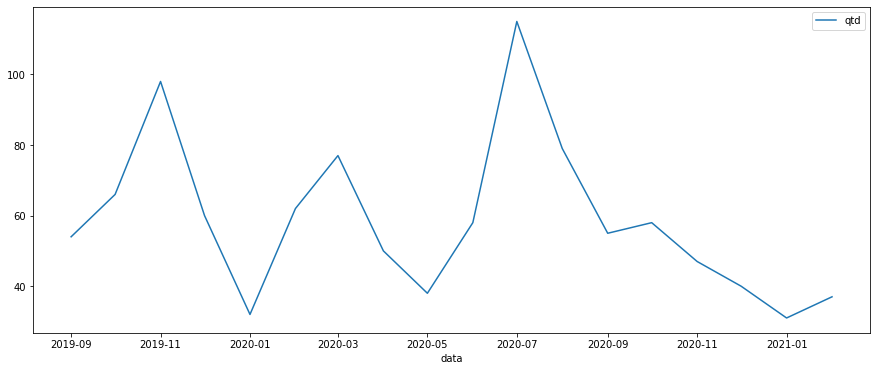

```python
plt.scatter(df_dados.index, df_dados['qtd'])
df_dados.plot(figsize=(15,6))
```

**Insight: Podemos ver um comportamento sazonal.**

**Abaixo vemos as diferenças das entradas em relação ao período anterior.**

```python
df_dados.qtd.diff()
```

```
data
2019-09-01     NaN
2019-10-01    12.0
2019-11-01    32.0
2019-12-01   -38.0
2020-01-01   -28.0
2020-02-01    30.0
2020-03-01    15.0
2020-04-01   -27.0
2020-05-01   -12.0
2020-06-01    20.0
2020-07-01    57.0
2020-08-01   -36.0
2020-09-01   -24.0
2020-10-01     3.0
2020-11-01   -11.0
2020-12-01    -7.0
2021-01-01    -9.0
2021-02-01     6.0
Name: qtd, dtype: float64
```

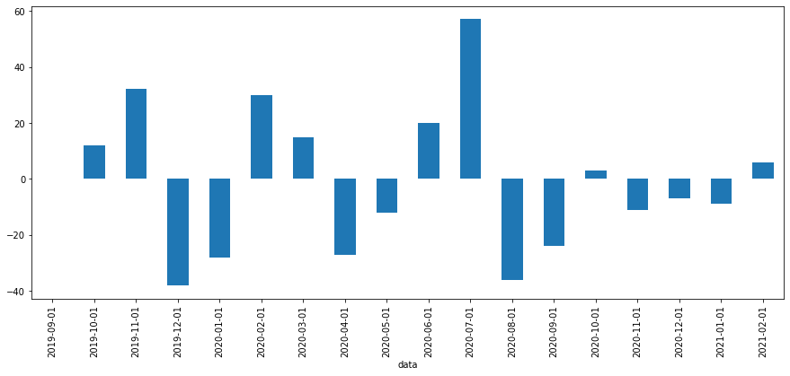

```python
df_dados.qtd.diff().plot(figsize=(15,6), kind='bar')
```

```python
df_dados.describe()
```

|  | qtd |
| --- | --- |
| count | 18.000000 |
| mean | 58.722222 |
| std | 22.368059 |
| min | 31.000000 |
| 25% | 41.750000 |
| 50% | 56.500000 |
| 75% | 65.000000 |
| max | 115.000000 |

**Acima temos uma tabela com as informações estatísticas do `df_dados`. A base possui 18 meses, com valor mínimo de 31, máximo de 115 e média de 59 na quantidade de entradas mensais.**

### 7. Aplicando algoritmo

#### 7.1. Modelo AR

```python
import warnings
warnings.filterwarnings('ignore')
from statsmodels.tsa.ar_model import AR
```

```python
ar_2 = AR(df_dados.qtd, freq='MS').fit(2)
(ar_2.resid ** 2).mean()
```

```
361.9892792431219
```

```python
ar_3 = AR(df_dados.qtd, freq='MS').fit(3)
(ar_3.resid ** 2).mean()
```

```
279.015560687248
```

```python
ar_4 = AR(df_dados.qtd, freq='MS').fit(4)
(ar_4.resid ** 2).mean()
```

```
281.62121700440133
```

**Observamos o erro quadrático médio em três versões de treinamento do modelo. A seguir utilizaremos o `ar_3` para comparar com os resultados reais.**

```python
df_dados['ar_3'] = ar_3.predict()
df_dados
```

| data | qtd | ar_3 |
| --- | --- | --- |
| 2019-09-01 | 54 | NaN |
| 2019-10-01 | 66 | NaN |
| 2019-11-01 | 98 | NaN |
| 2019-12-01 | 60 | 72.937771 |
| 2020-01-01 | 32 | 36.794383 |
| 2020-02-01 | 62 | 51.765643 |
| 2020-03-01 | 77 | 73.073948 |
| 2020-04-01 | 50 | 56.318644 |
| 2020-05-01 | 38 | 41.564963 |
| 2020-06-01 | 58 | 54.377460 |
| 2020-07-01 | 115 | 64.337004 |
| 2020-08-01 | 79 | 82.305067 |
| 2020-09-01 | 55 | 35.767464 |
| 2020-10-01 | 58 | 59.600297 |
| 2020-11-01 | 47 | 63.719076 |
| 2020-12-01 | 40 | 48.328995 |
| 2021-01-01 | 31 | 51.376775 |
| 2021-02-01 | 37 | 46.732510 |

**Adicionamos a coluna `ar_3` com os resultados previstos pelo modelo.**

**Vejamos a comparação.**

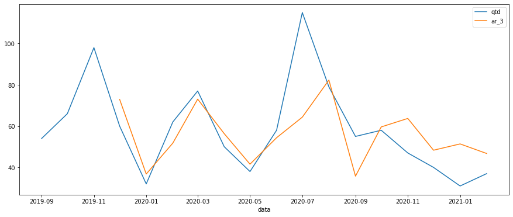

```python
df_dados.plot(figsize=(15,6))
```

**Agora com o modelo criado, vamos prever o mês seguinte e visualizar no gráfico.**

```python
ar_3.predict(start='2021-03-01', end='2021-03-01')
```

```
2021-03-01    53.082866
Freq: MS, dtype: float64
```

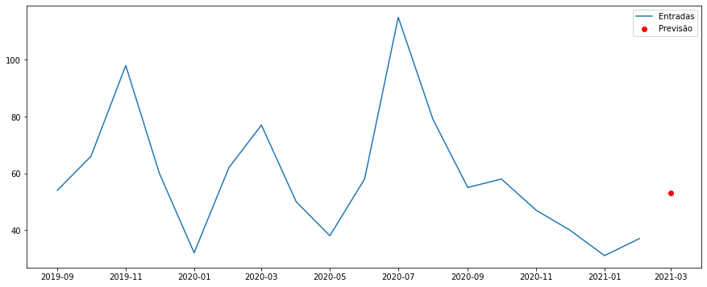

```python
plt.figure(figsize=(15,6))
plt.plot(df_dados.qtd)
previsao = ar_3.predict(start='2021-03-01', end='2021-03-01')
plt.scatter(previsao.index, previsao.values, color='red')
plt.legend(['Entradas', 'Previsão'])
```

**Para prever os demais meses, o modelo considera a previsão do mês anterior. Isto limite as previsões mais longas, sendo melhor analisar apesar um intervalo próximo. Vejamos abaixo como o modelo se comporta prevendo os dois próximos meses.**

```python
ar_3.predict(start='2021-03-01', end='2021-04-01')
```

```
2021-03-01    53.082866
2021-04-01    56.228938
Freq: MS, dtype: float64
```

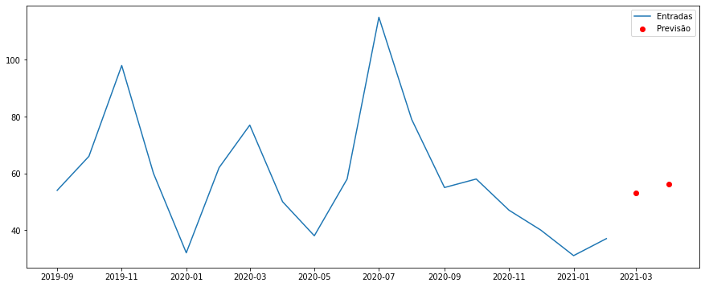

```python
plt.figure(figsize=(15,6))
plt.plot(df_dados.qtd)
previsao = ar_3.predict(start='2021-03-01', end='2021-04-01')
plt.scatter(previsao.index, previsao.values, color='red')
plt.legend(['Entradas', 'Previsão'])
```

**Agora prevendo os 6 próximo meses...**

```python
ar_3.predict(start='2021-03-01', end='2021-08-01')
```

```
2021-03-01    53.082866
2021-04-01    56.228938
2021-05-01    50.876049
2021-06-01    50.966574
2021-07-01    54.983100
2021-08-01    55.603965
Freq: MS, dtype: float64
```

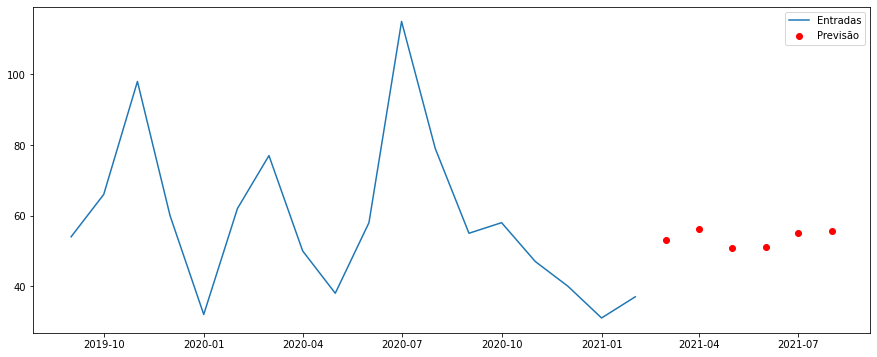

```python
plt.figure(figsize=(15,6))
plt.plot(df_dados.qtd)
previsao = ar_3.predict(start='2021-03-01', end='2021-08-01')
plt.scatter(previsao.index, previsao.values, color='red')
plt.legend(['Entradas', 'Previsão'])
```

**Por fim, vamos analisar o resultado entre este modelo e o `ar_4`.**

```python
df_dados['ar_4'] = ar_4.predict()
df_dados
```

| data | qtd | ar_3 | ar_4 |
| --- | --- | --- | --- |
| 2019-09-01 | 54 | NaN | NaN |
| 2019-10-01 | 66 | NaN | NaN |
| 2019-11-01 | 98 | NaN | NaN |
| 2019-12-01 | 60 | 72.937771 | NaN |
| 2020-01-01 | 32 | 36.794383 | 36.408307 |
| 2020-02-01 | 62 | 51.765643 | 51.581415 |
| 2020-03-01 | 77 | 73.073948 | 74.288499 |
| 2020-04-01 | 50 | 56.318644 | 58.127502 |
| 2020-05-01 | 38 | 41.564963 | 42.516259 |
| 2020-06-01 | 58 | 54.377460 | 54.682300 |
| 2020-07-01 | 115 | 64.337004 | 65.430175 |
| 2020-08-01 | 79 | 82.305067 | 89.752299 |
| 2020-09-01 | 55 | 35.767464 | 37.029721 |
| 2020-10-01 | 58 | 59.600297 | 62.243819 |
| 2020-11-01 | 47 | 63.719076 | 62.925761 |
| 2020-12-01 | 40 | 48.328995 | 46.958954 |
| 2021-01-01 | 31 | 51.376775 | 51.528794 |
| 2021-02-01 | 37 | 46.732510 | 45.526195 |

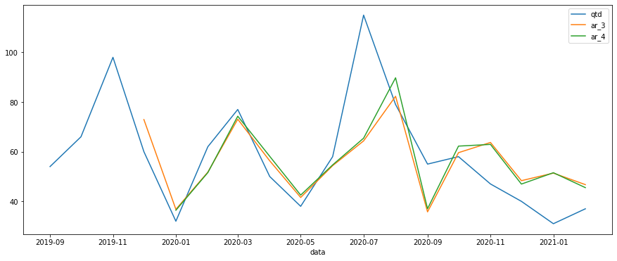

```python
df_dados.plot(figsize=(15,6))
```

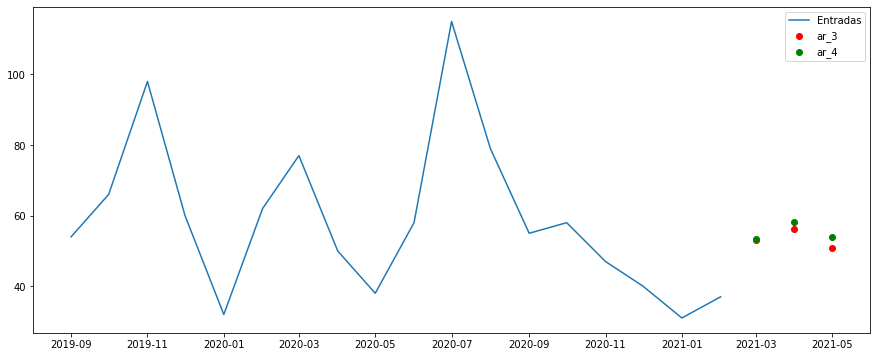

```python
plt.figure(figsize=(15,6))
plt.plot(df_dados.qtd)
previsao = ar_3.predict(start='2021-03-01', end='2021-05-01')
previsao2 = ar_4.predict(start='2021-03-01', end='2021-05-01')
plt.scatter(previsao.index, previsao.values, color='red')
plt.scatter(previsao2.index, previsao2.values, color='green')
plt.legend(['Entradas', 'ar_3', 'ar_4'])
```

#### 8. Conclusão

O trabalho teve um cunho mais voltado ao aprendizado, embora seja possível ter uma boa percepção em relação ao resultado obtido para visualizar tendências. Em relação a previsão, é importante testar outros modelos para obter um erro menor e embasar uma solução mais robusta para garantir previsões adequadas a tomada de decisões.